[figure not shown]

# Spatial Map

This short notebook will guide you over loading data and using [`SpatialMap`](https://ryanharvey1.github.io/neuro_py/reference/neuro_py/tuning/maps/#neuro_py.tuning.maps.SpatialMap) class.

We first go over 2D maps and then have 1D maps, and finally mapping continuous variables.

## Setup

```python
%reload_ext autoreload
%autoreload 2

import matplotlib.pyplot as plt
import nelpy as nel
import nelpy.plotting as npl
import numpy as np
import seaborn as sns
from skimage import measure

import neuro_py as npy
from neuro_py.behavior.linear_positions import get_linear_track_lap_epochs
from neuro_py.ensemble.assembly_reactivation import AssemblyReact
from neuro_py.io import loading
from neuro_py.plotting.figure_helpers import set_size
from neuro_py.tuning import maps

%matplotlib inline
%config InlineBackend.figure_format = 'retina'

import logging

logging.getLogger().setLevel(logging.ERROR)
```

%reload_ext autoreload %autoreload 2 import matplotlib.pyplot as plt import nelpy as nel import nelpy.plotting as npl import numpy as np import seaborn as sns from skimage import measure import neuro_py as npy from neuro_py.behavior.linear_positions import get_linear_track_lap_epochs from neuro_py.ensemble.assembly_reactivation import AssemblyReact from neuro_py.io import loading from neuro_py.plotting.figure_helpers import set_size from neuro_py.tuning import maps %matplotlib inline %config InlineBackend.figure_format = 'retina' import logging logging.getLogger().setLevel(logging.ERROR)

## Section 1: Specify basepath to your session of interest

```python
basepath = r"Z:\Data\Kenji\ec013.961_974"
```

basepath = r"Z:\Data\Kenji\ec013.961_974"

## Section 2: load in behavior and spike data

```python
# load position
position_df = loading.load_animal_behavior(basepath)

# put position into a nelpy position array for ease of use
pos = nel.AnalogSignalArray(
    data=position_df[["x", "y"]].values.T,
    timestamps=position_df.timestamps.values,
)
# calculate speed
speed = nel.utils.ddt_asa(pos, smooth=True, sigma=0.250, norm=True)

# load in spike data from hpc pyramidal cells
st, cm = loading.load_spikes(
    basepath, putativeCellType="Pyr", brainRegion="CA1|CA2|CA3"
)
```

# load position position_df = loading.load_animal_behavior(basepath) # put position into a nelpy position array for ease of use pos = nel.AnalogSignalArray( data=position_df[["x", "y"]].values.T, timestamps=position_df.timestamps.values, ) # calculate speed speed = nel.utils.ddt_asa(pos, smooth=True, sigma=0.250, norm=True) # load in spike data from hpc pyramidal cells st, cm = loading.load_spikes( basepath, putativeCellType="Pyr", brainRegion="CA1|CA2|CA3" )

## Section 3: Load in epochs and make a note of which session you want to analyze

Here, I'm first interested in the last *bigSquare* session

```python
epoch_df = loading.load_epoch(basepath)
beh_epochs = nel.EpochArray(np.array([epoch_df.startTime, epoch_df.stopTime]).T)

# you can change this based on which session you want to look at
behavior_idx = 11

# print out data frame
epoch_df
```

epoch_df = loading.load_epoch(basepath) beh_epochs = nel.EpochArray(np.array([epoch_df.startTime, epoch_df.stopTime]).T) # you can change this based on which session you want to look at behavior_idx = 11 # print out data frame epoch_df

|  | name | startTime | stopTime | environment | behavioralParadigm | manipulation | stimuli | notes | basepath |
| --- | --- | --- | --- | --- | --- | --- | --- | --- | --- |
| 0 | ec013.961_sleep | 0.0000 | 321.9456 | sleep | 10 | NaN | NaN | NaN | Z:\Data\Kenji\ec013.961_974 |
| 1 | ec013.962_sleep | 321.9456 | 2475.2456 | sleep | 10 | NaN | NaN | NaN | Z:\Data\Kenji\ec013.961_974 |
| 2 | ec013.963_sleep | 2475.2456 | 5748.3596 | sleep | 10 | NaN | NaN | NaN | Z:\Data\Kenji\ec013.961_974 |
| 3 | ec013.964_sleep | 5748.3596 | 6035.4892 | sleep | 10 | NaN | NaN | NaN | Z:\Data\Kenji\ec013.961_974 |
| 4 | ec013.965_linear | 6035.4892 | 7481.7872 | linear | 10 | NaN | NaN | NaN | Z:\Data\Kenji\ec013.961_974 |
| 5 | ec013.966_linear | 7481.7872 | 9050.3872 | linear | 10 | NaN | NaN | NaN | Z:\Data\Kenji\ec013.961_974 |
| 6 | ec013.967_sleep | 9050.3872 | 10959.9422 | sleep | 10 | NaN | NaN | NaN | Z:\Data\Kenji\ec013.961_974 |
| 7 | ec013.968_sleep | 10959.9422 | 13312.2752 | sleep | 10 | NaN | NaN | NaN | Z:\Data\Kenji\ec013.961_974 |
| 8 | ec013.969_linear | 13312.2752 | 15073.9652 | linear | 10 | NaN | NaN | NaN | Z:\Data\Kenji\ec013.961_974 |
| 9 | ec013.970_bigSquare | 15073.9652 | 17064.4652 | bigSquare | 10 | NaN | NaN | NaN | Z:\Data\Kenji\ec013.961_974 |
| 10 | ec013.971_bigSquare | 17064.4652 | 18704.5652 | bigSquare | 10 | NaN | NaN | NaN | Z:\Data\Kenji\ec013.961_974 |
| 11 | ec013.972_bigSquare | 18704.5652 | 21714.0652 | bigSquare | 10 | NaN | NaN | NaN | Z:\Data\Kenji\ec013.961_974 |
| 12 | ec013.973_wheel | 21714.0652 | 23200.5032 | wheel | 10 | NaN | NaN | NaN | Z:\Data\Kenji\ec013.961_974 |
| 13 | ec013.974_wheel | 23200.5032 | 24717.6612 | wheel | 10 | NaN | NaN | NaN | Z:\Data\Kenji\ec013.961_974 |

## Section 4: Make tuning curves and detect 2D place fields using the SpatialMap class

You can see I am specifying positions and spikes within our epoch of choice

There are many other parameters you can change, so check out the documentation of the class

```python
spatial_maps = maps.SpatialMap(
    pos[beh_epochs[behavior_idx]],
    st[beh_epochs[behavior_idx]],
    s_binsize=3,
    speed=speed,
    speed_thres=4,
    tuning_curve_sigma=3,
    place_field_min_size=15,
    place_field_max_size=1000,
    place_field_sigma=3,
)
spatial_maps.find_fields()

spatial_maps
```

spatial_maps = maps.SpatialMap( pos[beh_epochs[behavior_idx]], st[beh_epochs[behavior_idx]], s_binsize=3, speed=speed, speed_thres=4, tuning_curve_sigma=3, place_field_min_size=15, place_field_max_size=1000, place_field_sigma=3, ) spatial_maps.find_fields() spatial_maps

```
<TuningCurve2D at 0x21bf1c04e90> with shape (16, 64, 64)
```

You can also shuffle your data to find which cell has more spatial information than chance. Depending on how many cells you have this can take a bit of time, but it shouldn't take more than a minute with the default 500 shuffles.

```python
spatial_info_pvalues = spatial_maps.shuffle_spatial_information()
```

spatial_info_pvalues = spatial_maps.shuffle_spatial_information()

There are many more class methods available within `spatial_maps.tc`:

```python
[k for k in dir(spatial_maps.tc) if not k.startswith("_")]
```

[k for k in dir(spatial_maps.tc) if not k.startswith("_")]

```
['bin_centers',
 'bins',
 'field_mask',
 'field_peak_rate',
 'field_width',
 'information_rate',
 'is2d',
 'isempty',
 'label',
 'mask',
 'max',
 'mean',
 'min',
 'n_bins',
 'n_fields',
 'n_units',
 'n_xbins',
 'n_ybins',
 'normalize',
 'occupancy',
 'ratemap',
 'reorder_units_by_ids',
 'shape',
 'smooth',
 'spatial_information',
 'spatial_selectivity',
 'spatial_sparsity',
 'std',
 'unit_ids',
 'unit_labels',
 'unit_tags',
 'xbin_centers',
 'xbins',
 'ybin_centers',
 'ybins']
```

## Section 5: Inspect the results by looking at the tuning curves and spikes on path plots

```python
# pull out velocity restricted position
current_pos = pos[beh_epochs[behavior_idx]][spatial_maps.run_epochs]

spatial_information = spatial_maps.spatial_information()

# iterate over the tuning curves
for ratemap_i, ratemap__ in enumerate(spatial_maps.tc.ratemap):
    ratemap_ = ratemap__.copy()
    ratemap_[spatial_maps.tc.occupancy < 0.01] = np.nan
    fig, ax = plt.subplots(1, 2, figsize=(10, 5))
    sns.heatmap(ratemap_.T, ax=ax[0])

    field_ids = np.unique(spatial_maps.tc.field_mask[ratemap_i])

    # plot field boundaries over the heat map
    if len(field_ids) > 1:
        for field_i in range(len(field_ids) - 1):
            bc = measure.find_contours(
                (spatial_maps.tc.field_mask[ratemap_i] == field_i + 1).T,
                0,
                fully_connected="low",
                positive_orientation="low",
            )
            for c in bc:
                ax[0].plot(c[:, 1], c[:, 0], linewidth=4)
    ax[0].invert_yaxis()

    # plot xy coords for animal position
    npl.plot2d(current_pos, lw=2, c="0.8", ax=ax[1])

    # plot xy coords for each spike
    x_time, pos_at_spikes = pos.asarray(
        at=st[beh_epochs[behavior_idx]][spatial_maps.run_epochs].data[ratemap_i]
    )
    ax[1].plot(pos_at_spikes[0, :], pos_at_spikes[1, :], ".", color="k")
    ax[1].set_aspect("equal")
    ax[0].set_aspect("equal")
    ax[1].set_title(f"{cm.iloc[ratemap_i].brainRegion} {cm.iloc[ratemap_i].UID}")
    ax[0].set_title(
        f"field width, {spatial_maps.tc.field_width[ratemap_i]:.2f}. peak rate {spatial_maps.tc.field_peak_rate[ratemap_i]:.2f}. \n info: {spatial_information[ratemap_i]:.2f}, pval: {spatial_info_pvalues[ratemap_i]:.3f}, Z: {spatial_maps.spatial_information_zscore[ratemap_i]:.2f}"
    )
    sns.despine()
    plt.show()
```

# pull out velocity restricted position current_pos = pos[beh_epochs[behavior_idx]][spatial_maps.run_epochs] spatial_information = spatial_maps.spatial_information() # iterate over the tuning curves for ratemap_i, ratemap__ in enumerate(spatial_maps.tc.ratemap): ratemap_ = ratemap__.copy() ratemap_[spatial_maps.tc.occupancy < 0.01] = np.nan fig, ax = plt.subplots(1, 2, figsize=(10, 5)) sns.heatmap(ratemap_.T, ax=ax[0]) field_ids = np.unique(spatial_maps.tc.field_mask[ratemap_i]) # plot field boundaries over the heat map if len(field_ids) > 1: for field_i in range(len(field_ids) - 1): bc = measure.find_contours( (spatial_maps.tc.field_mask[ratemap_i] == field_i + 1).T, 0, fully_connected="low", positive_orientation="low", ) for c in bc: ax[0].plot(c[:, 1], c[:, 0], linewidth=4) ax[0].invert_yaxis() # plot xy coords for animal position npl.plot2d(current_pos, lw=2, c="0.8", ax=ax[1]) # plot xy coords for each spike x_time, pos_at_spikes = pos.asarray( at=st[beh_epochs[behavior_idx]][spatial_maps.run_epochs].data[ratemap_i] ) ax[1].plot(pos_at_spikes[0, :], pos_at_spikes[1, :], ".", color="k") ax[1].set_aspect("equal") ax[0].set_aspect("equal") ax[1].set_title(f"{cm.iloc[ratemap_i].brainRegion} {cm.iloc[ratemap_i].UID}") ax[0].set_title( f"field width, {spatial_maps.tc.field_width[ratemap_i]:.2f}. peak rate {spatial_maps.tc.field_peak_rate[ratemap_i]:.2f}. \n info: {spatial_information[ratemap_i]:.2f}, pval: {spatial_info_pvalues[ratemap_i]:.3f}, Z: {spatial_maps.spatial_information_zscore[ratemap_i]:.2f}" ) sns.despine() plt.show()

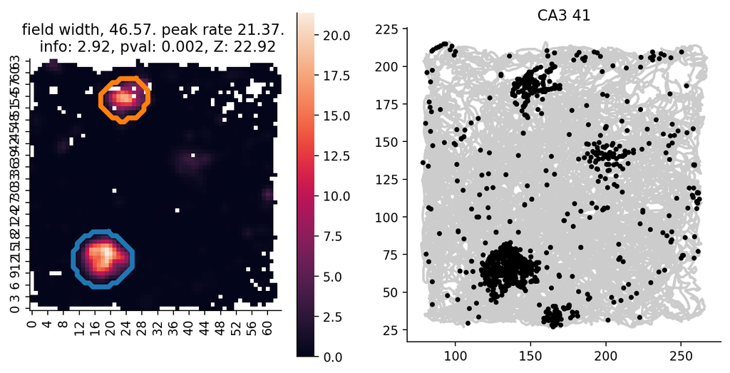

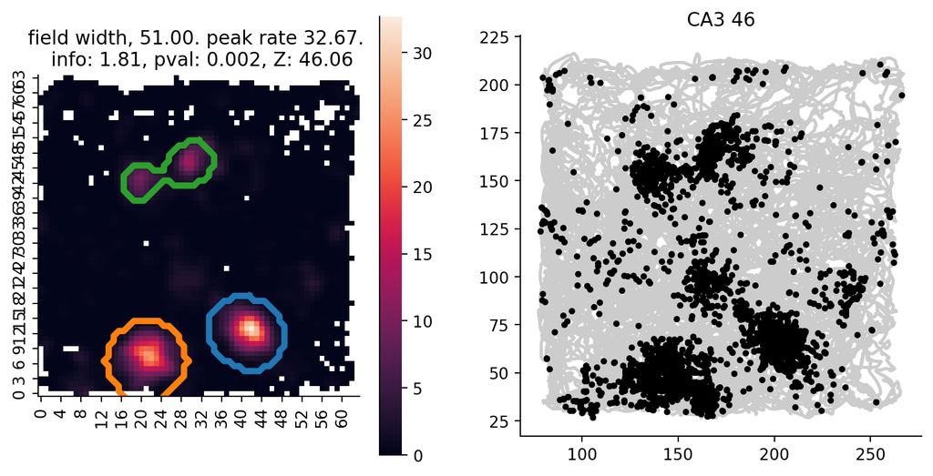

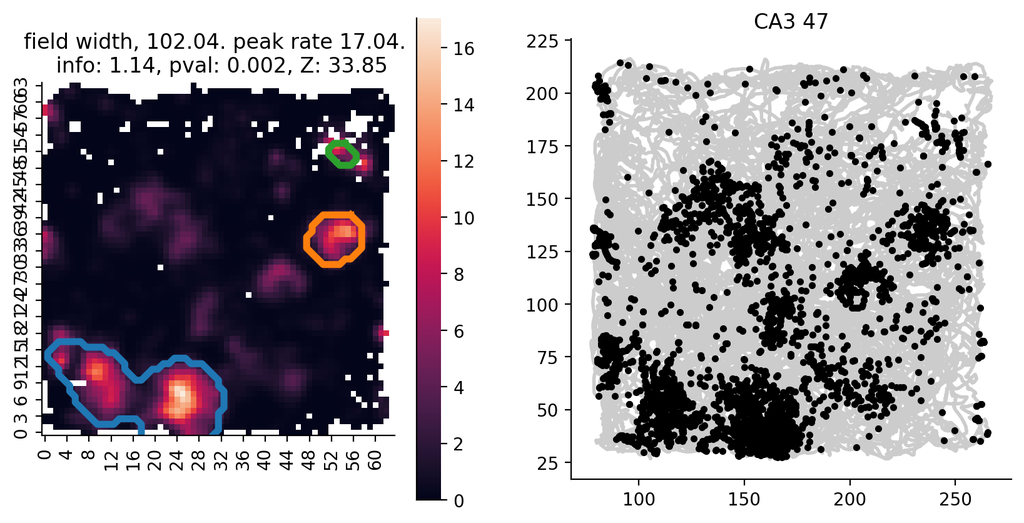

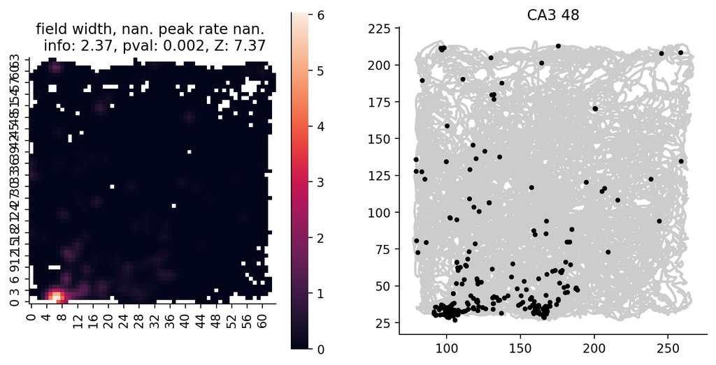

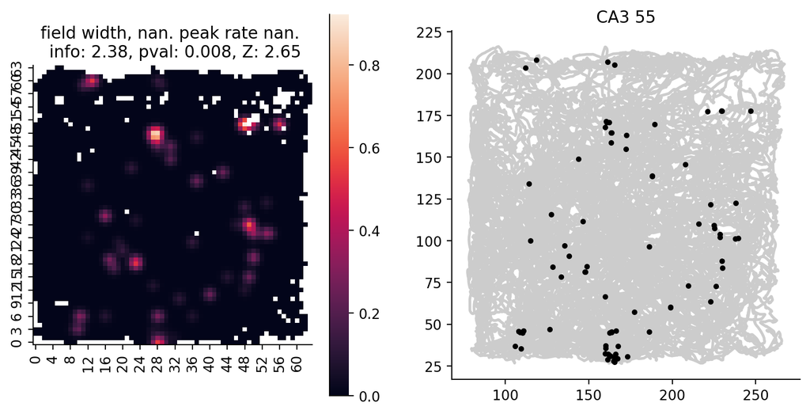

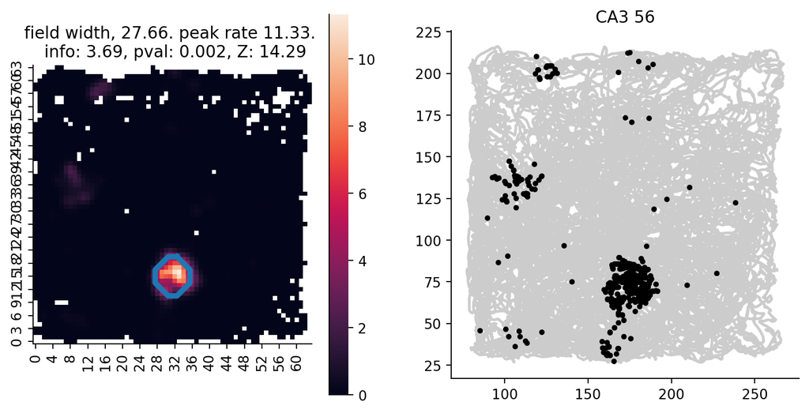

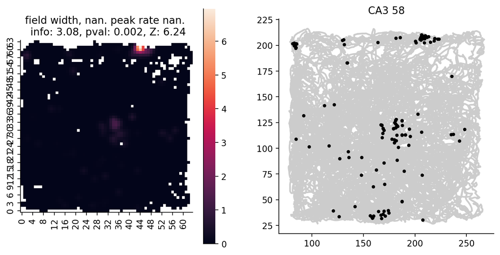

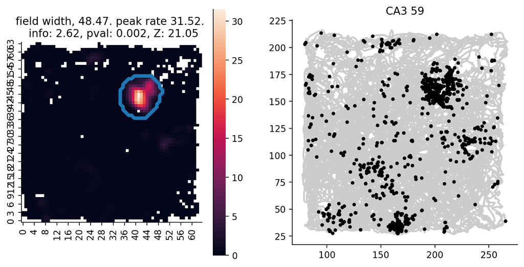

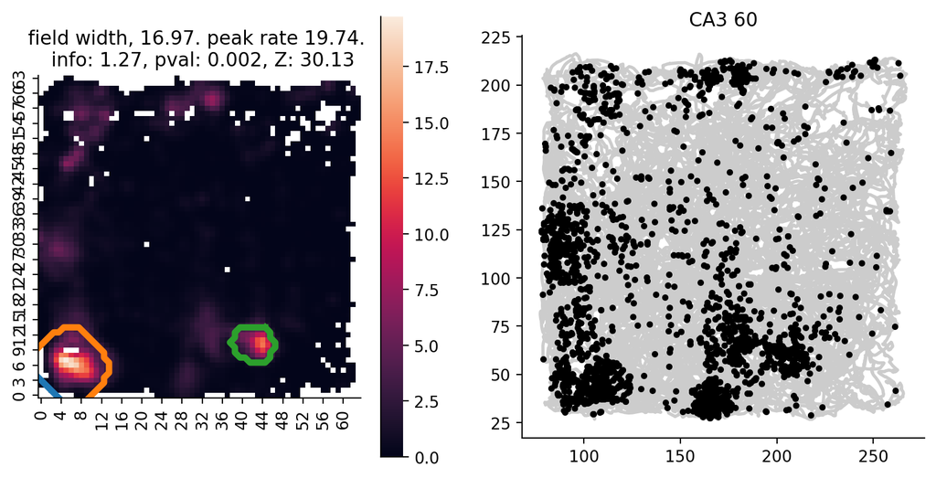

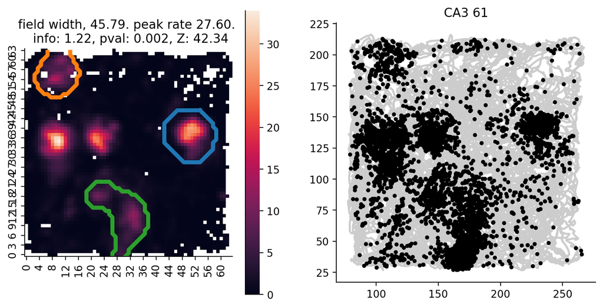

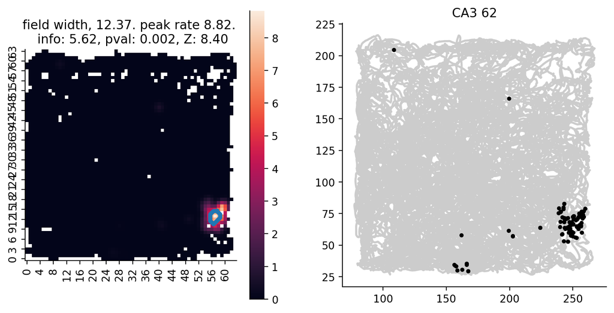

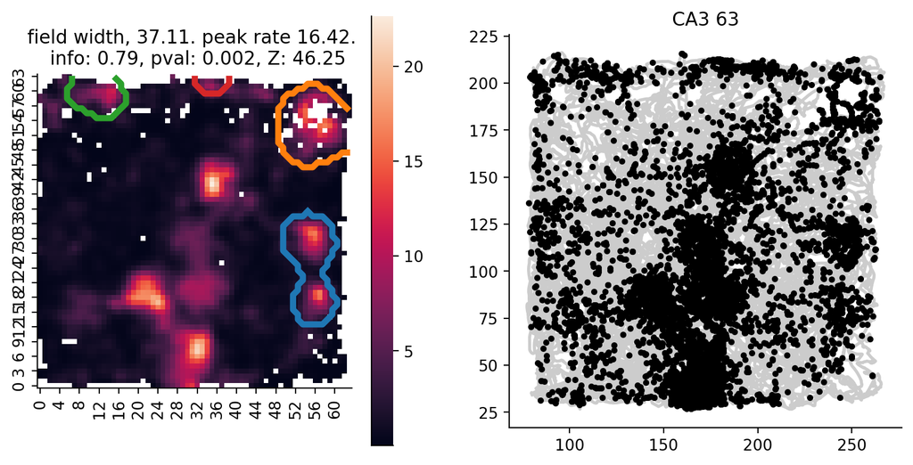

[4 more figures not shown]

## Section 6: Now lets make 1D maps using the same class

```python
# change to the first linear track session
behavior_idx = 4

# print out data frame
epoch_df
```

# change to the first linear track session behavior_idx = 4 # print out data frame epoch_df

|  | name | startTime | stopTime | environment | behavioralParadigm | manipulation | stimuli | notes | basepath |
| --- | --- | --- | --- | --- | --- | --- | --- | --- | --- |
| 0 | ec013.961_sleep | 0.0000 | 321.9456 | sleep | 10 | NaN | NaN | NaN | Z:\Data\Kenji\ec013.961_974 |
| 1 | ec013.962_sleep | 321.9456 | 2475.2456 | sleep | 10 | NaN | NaN | NaN | Z:\Data\Kenji\ec013.961_974 |
| 2 | ec013.963_sleep | 2475.2456 | 5748.3596 | sleep | 10 | NaN | NaN | NaN | Z:\Data\Kenji\ec013.961_974 |
| 3 | ec013.964_sleep | 5748.3596 | 6035.4892 | sleep | 10 | NaN | NaN | NaN | Z:\Data\Kenji\ec013.961_974 |
| 4 | ec013.965_linear | 6035.4892 | 7481.7872 | linear | 10 | NaN | NaN | NaN | Z:\Data\Kenji\ec013.961_974 |
| 5 | ec013.966_linear | 7481.7872 | 9050.3872 | linear | 10 | NaN | NaN | NaN | Z:\Data\Kenji\ec013.961_974 |
| 6 | ec013.967_sleep | 9050.3872 | 10959.9422 | sleep | 10 | NaN | NaN | NaN | Z:\Data\Kenji\ec013.961_974 |
| 7 | ec013.968_sleep | 10959.9422 | 13312.2752 | sleep | 10 | NaN | NaN | NaN | Z:\Data\Kenji\ec013.961_974 |
| 8 | ec013.969_linear | 13312.2752 | 15073.9652 | linear | 10 | NaN | NaN | NaN | Z:\Data\Kenji\ec013.961_974 |
| 9 | ec013.970_bigSquare | 15073.9652 | 17064.4652 | bigSquare | 10 | NaN | NaN | NaN | Z:\Data\Kenji\ec013.961_974 |
| 10 | ec013.971_bigSquare | 17064.4652 | 18704.5652 | bigSquare | 10 | NaN | NaN | NaN | Z:\Data\Kenji\ec013.961_974 |
| 11 | ec013.972_bigSquare | 18704.5652 | 21714.0652 | bigSquare | 10 | NaN | NaN | NaN | Z:\Data\Kenji\ec013.961_974 |
| 12 | ec013.973_wheel | 21714.0652 | 23200.5032 | wheel | 10 | NaN | NaN | NaN | Z:\Data\Kenji\ec013.961_974 |
| 13 | ec013.974_wheel | 23200.5032 | 24717.6612 | wheel | 10 | NaN | NaN | NaN | Z:\Data\Kenji\ec013.961_974 |

### Section 6.1: Reconstruct the position array with linearized coords

Note, you can see if you print out `nelpy` arrays, there is very helpful information.

```python
pos = nel.AnalogSignalArray(
    data=position_df["linearized"].values.T,
    timestamps=position_df.timestamps.values,
)
pos = pos[beh_epochs[behavior_idx]]
speed = nel.utils.ddt_asa(pos, smooth=True, sigma=0.250, norm=True)
pos
```

pos = nel.AnalogSignalArray( data=position_df["linearized"].values.T, timestamps=position_df.timestamps.values, ) pos = pos[beh_epochs[behavior_idx]] speed = nel.utils.ddt_asa(pos, smooth=True, sigma=0.250, norm=True) pos

```
<AnalogSignalArray at 0x21bf37a5090: 1 signals> for a total of 24:06:298 minutes
```

### Section 6.2: Visualize the 1D position

```python
plt.figure(figsize=(20, 4))
plt.plot(pos.data.T)
```

plt.figure(figsize=(20, 4)) plt.plot(pos.data.T)

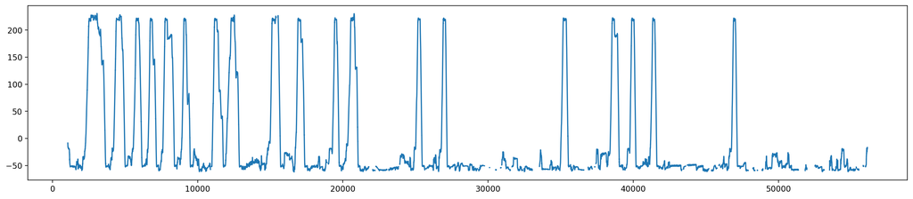

### Section 6.2: Get outbound and inbound epochs

```python
# get outbound and inbound epochs
(outbound_epochs, inbound_epochs) = get_linear_track_lap_epochs(
    pos.abscissa_vals, pos.data[0], newLapThreshold=20
)


outbound_epochs, inbound_epochs
```

# get outbound and inbound epochs (outbound_epochs, inbound_epochs) = get_linear_track_lap_epochs( pos.abscissa_vals, pos.data[0], newLapThreshold=20 ) outbound_epochs, inbound_epochs

```
(<EpochArray at 0x21bf3456c50: 19 epochs> of length 9:45:574 minutes,
 <EpochArray at 0x21bf34468d0: 20 epochs> of length 13:36:844 minutes)
```

```python
plt.figure(figsize=(20, 4))
plt.scatter(
    pos[outbound_epochs].abscissa_vals,
    pos[outbound_epochs].data,
    color="r",
    s=1,
    label="outbound_epochs",
)
plt.scatter(
    pos[inbound_epochs].abscissa_vals,
    pos[inbound_epochs].data,
    color="b",
    s=1,
    label="inbound_epochs",
)
plt.legend()
```

plt.figure(figsize=(20, 4)) plt.scatter( pos[outbound_epochs].abscissa_vals, pos[outbound_epochs].data, color="r", s=1, label="outbound_epochs", ) plt.scatter( pos[inbound_epochs].abscissa_vals, pos[inbound_epochs].data, color="b", s=1, label="inbound_epochs", ) plt.legend()

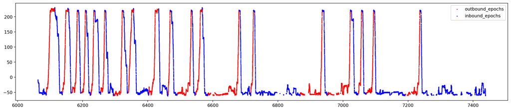

### Section 6.3: Make tuning curves for the outbound trajectories

```python
spatial_maps = maps.SpatialMap(
    pos[outbound_epochs],
    st[outbound_epochs],
    place_field_min_size=5,
    tuning_curve_sigma=4,
    place_field_sigma=0.1,
)
spatial_maps.find_fields()
```

spatial_maps = maps.SpatialMap( pos[outbound_epochs], st[outbound_epochs], place_field_min_size=5, tuning_curve_sigma=4, place_field_sigma=0.1, ) spatial_maps.find_fields()

### Section 6.4: Visualize the tuning curves

```python
tc = spatial_maps.tc

w, h = set_size("thesis", fraction=0.3, subplots=(3, 1))

with npl.FigureManager(show=True, figsize=(w, h)) as (fig_, ax):
    npl.utils.skip_if_no_output(fig_)
    ax1 = npl.plot_tuning_curves1D(
        tc.reorder_units(), normalize=True, pad=1, fill=True, alpha=0.5
    )

    leg_lines = ax1.get_lines()
    plt.setp(leg_lines, linewidth=0.5)
    ax.set_xlabel("position (cm)")
    ax.set_ylabel("n pyr cells")
    ax.set_xticks([0, tc.bins.max()])
```

tc = spatial_maps.tc w, h = set_size("thesis", fraction=0.3, subplots=(3, 1)) with npl.FigureManager(show=True, figsize=(w, h)) as (fig_, ax): npl.utils.skip_if_no_output(fig_) ax1 = npl.plot_tuning_curves1D( tc.reorder_units(), normalize=True, pad=1, fill=True, alpha=0.5 ) leg_lines = ax1.get_lines() plt.setp(leg_lines, linewidth=0.5) ax.set_xlabel("position (cm)") ax.set_ylabel("n pyr cells") ax.set_xticks([0, tc.bins.max()])

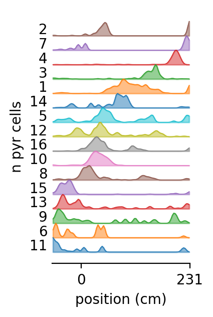

### Section 6.5: Inspect the field detection

```python
for ratemap_i, ratemap__ in enumerate(spatial_maps.tc.ratemap):
    ratemap_ = ratemap__.copy()
    x = np.arange(len(ratemap_)) * spatial_maps.s_binsize
    plt.figure(figsize=(5, 2))
    plt.plot(x, ratemap_, color="k")
    # field_ids = np.unique(spatial_maps.tc.field_mask[ratemap_i])
    # plt.plot(x, spatial_maps.tc.field_mask[ratemap_i], color="r")
    for interval in x[
        npy.process.find_interval(spatial_maps.tc.field_mask[ratemap_i] != 0)
    ]:
        plt.axvspan(interval[0], interval[1], alpha=0.3)
    plt.title(
        f"field width, {spatial_maps.tc.field_width[ratemap_i]:.2f}. peak rate {spatial_maps.tc.field_peak_rate[ratemap_i]:.2f}."
    )
    plt.ylabel("firing rate (Hz)")
    plt.xlabel("position (cm)")
    sns.despine()
    plt.show()
```

for ratemap_i, ratemap__ in enumerate(spatial_maps.tc.ratemap): ratemap_ = ratemap__.copy() x = np.arange(len(ratemap_)) * spatial_maps.s_binsize plt.figure(figsize=(5, 2)) plt.plot(x, ratemap_, color="k") # field_ids = np.unique(spatial_maps.tc.field_mask[ratemap_i]) # plt.plot(x, spatial_maps.tc.field_mask[ratemap_i], color="r") for interval in x[ npy.process.find_interval(spatial_maps.tc.field_mask[ratemap_i] != 0) ]: plt.axvspan(interval[0], interval[1], alpha=0.3) plt.title( f"field width, {spatial_maps.tc.field_width[ratemap_i]:.2f}. peak rate {spatial_maps.tc.field_peak_rate[ratemap_i]:.2f}." ) plt.ylabel("firing rate (Hz)") plt.xlabel("position (cm)") sns.despine() plt.show()

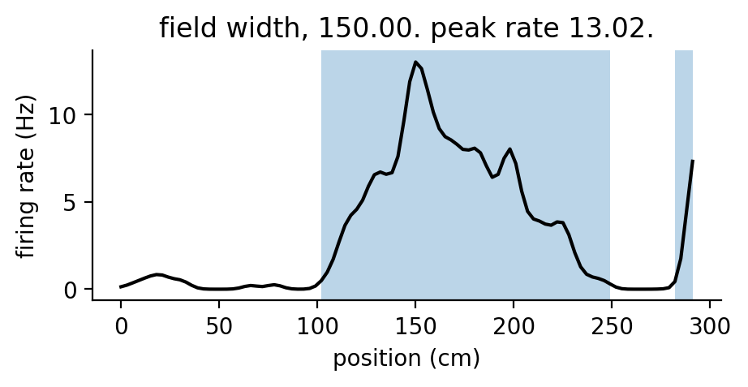

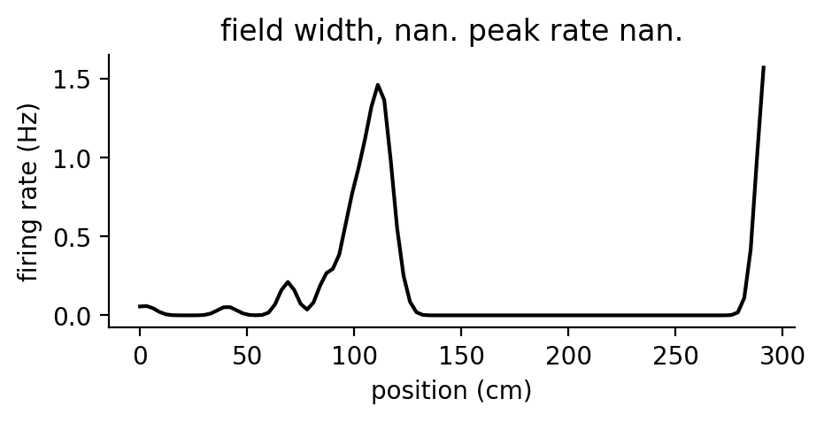

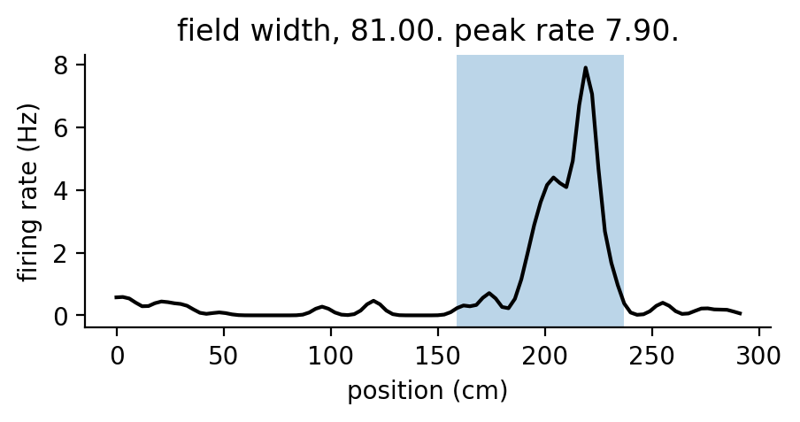

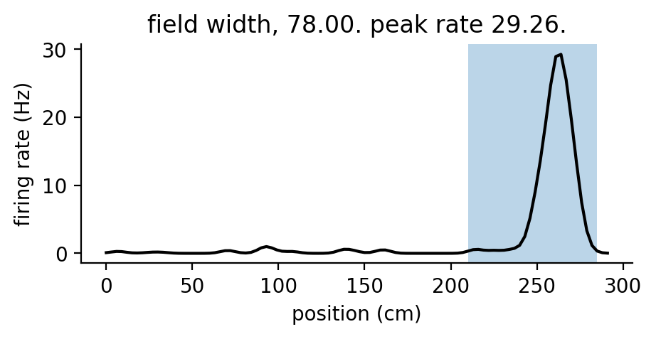

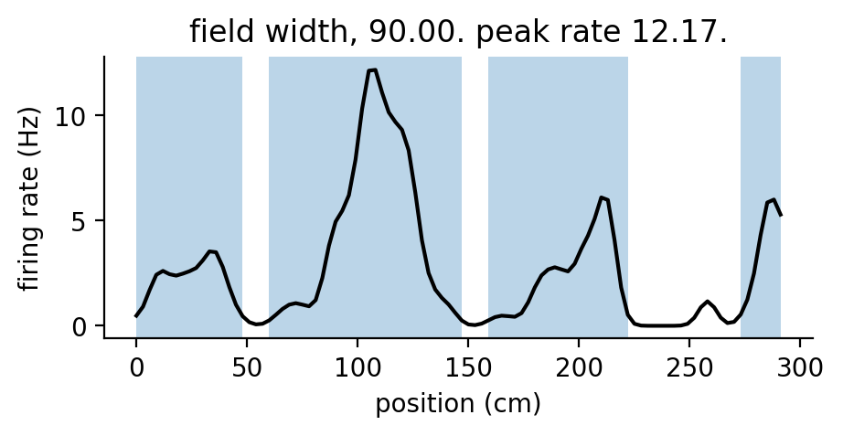

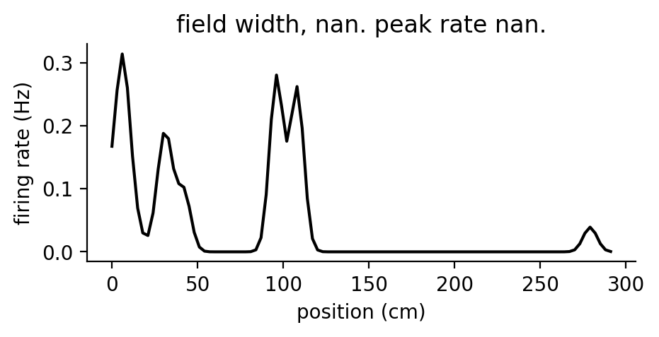

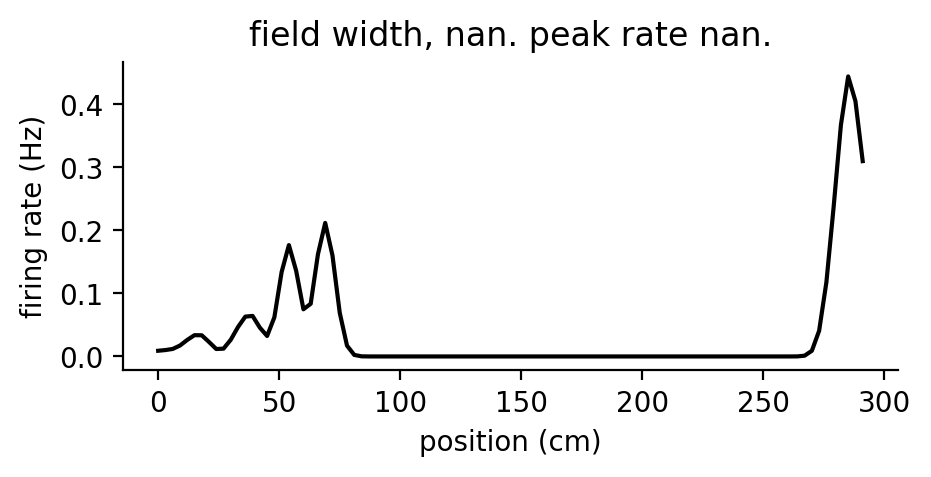

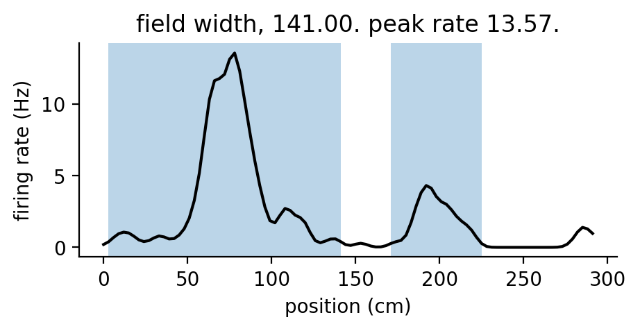

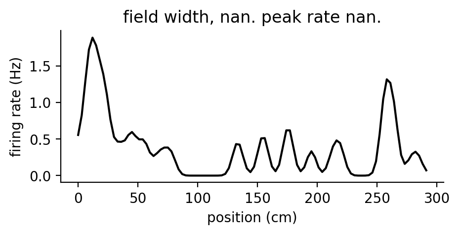

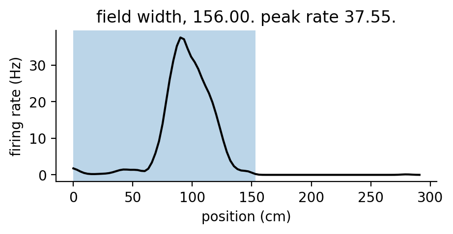

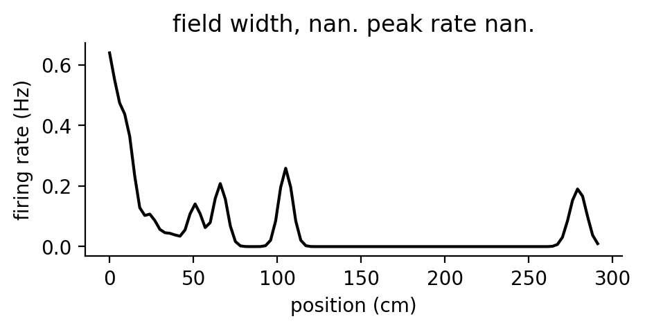

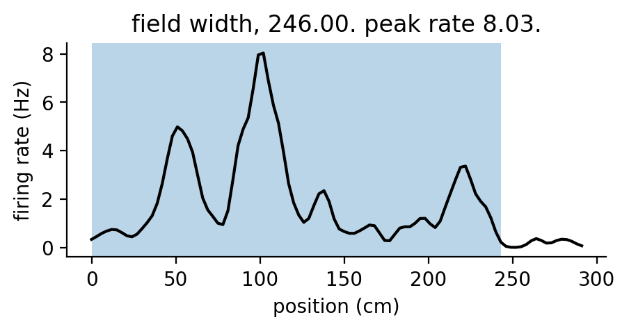

[4 more figures not shown]

```python
# pull out velocity restricted position
current_pos = pos[beh_epochs[behavior_idx]][spatial_maps.run_epochs]

# iterate over the tuning curves
for ratemap_i, ratemap__ in enumerate(spatial_maps.tc.ratemap):
    ratemap_ = ratemap__.copy()
    ratemap_[spatial_maps.tc.occupancy < 0.01] = np.nan
    fig, ax = plt.subplots(
        2, 1, figsize=(5, 3), sharex=True, gridspec_kw={"height_ratios": [1, 3]}
    )

    # plot tuning curve
    x = (spatial_maps.x_edges + np.abs(np.diff(spatial_maps.x_edges)[0] / 2))[:-1]
    ax[0].plot(x, ratemap_, color="k")

    # plot xy coords for animal position
    ax[1].plot(current_pos.data.T, current_pos.abscissa_vals, "grey")

    # plot xy coords for each spike
    x_time, pos_at_spikes = pos.asarray(
        at=st[beh_epochs[behavior_idx]][spatial_maps.run_epochs].data[ratemap_i]
    )
    ax[1].plot(pos_at_spikes.flatten(), x_time, ".", color="k")

    for interval in x[
        npy.process.find_interval(spatial_maps.tc.field_mask[ratemap_i] != 0)
    ]:
        ax[0].axvspan(interval[0], interval[1], alpha=0.3)
        ax[1].axvspan(interval[0], interval[1], alpha=0.3)

    ax[1].set_xlim(x.min(), x.max())

    # add figure labels
    ax[0].set_ylabel("rate (Hz)")
    ax[1].set_ylabel("time (sec)")
    ax[1].set_xlabel("position (cm)")

    ax[0].set_title(
        f"field width, {spatial_maps.tc.field_width[ratemap_i]:.2f}. peak rate {spatial_maps.tc.field_peak_rate[ratemap_i]:.2f} {cm.iloc[ratemap_i].brainRegion} {cm.iloc[ratemap_i].UID}"
    )
    sns.despine()
    plt.show()
```

# pull out velocity restricted position current_pos = pos[beh_epochs[behavior_idx]][spatial_maps.run_epochs] # iterate over the tuning curves for ratemap_i, ratemap__ in enumerate(spatial_maps.tc.ratemap): ratemap_ = ratemap__.copy() ratemap_[spatial_maps.tc.occupancy < 0.01] = np.nan fig, ax = plt.subplots( 2, 1, figsize=(5, 3), sharex=True, gridspec_kw={"height_ratios": [1, 3]} ) # plot tuning curve x = (spatial_maps.x_edges + np.abs(np.diff(spatial_maps.x_edges)[0] / 2))[:-1] ax[0].plot(x, ratemap_, color="k") # plot xy coords for animal position ax[1].plot(current_pos.data.T, current_pos.abscissa_vals, "grey") # plot xy coords for each spike x_time, pos_at_spikes = pos.asarray( at=st[beh_epochs[behavior_idx]][spatial_maps.run_epochs].data[ratemap_i] ) ax[1].plot(pos_at_spikes.flatten(), x_time, ".", color="k") for interval in x[ npy.process.find_interval(spatial_maps.tc.field_mask[ratemap_i] != 0) ]: ax[0].axvspan(interval[0], interval[1], alpha=0.3) ax[1].axvspan(interval[0], interval[1], alpha=0.3) ax[1].set_xlim(x.min(), x.max()) # add figure labels ax[0].set_ylabel("rate (Hz)") ax[1].set_ylabel("time (sec)") ax[1].set_xlabel("position (cm)") ax[0].set_title( f"field width, {spatial_maps.tc.field_width[ratemap_i]:.2f}. peak rate {spatial_maps.tc.field_peak_rate[ratemap_i]:.2f} {cm.iloc[ratemap_i].brainRegion} {cm.iloc[ratemap_i].UID}" ) sns.despine() plt.show()

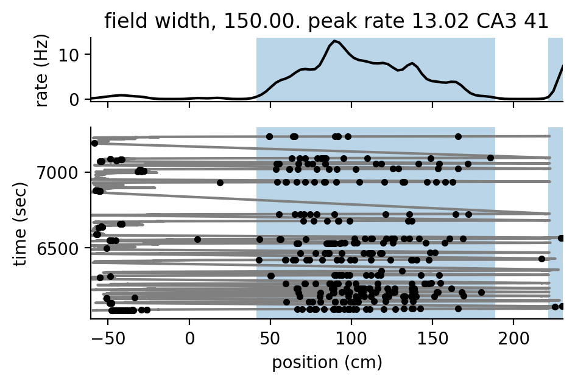

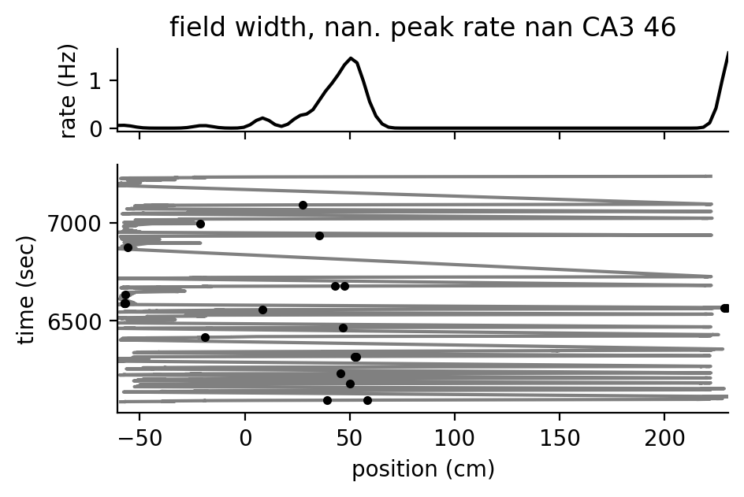

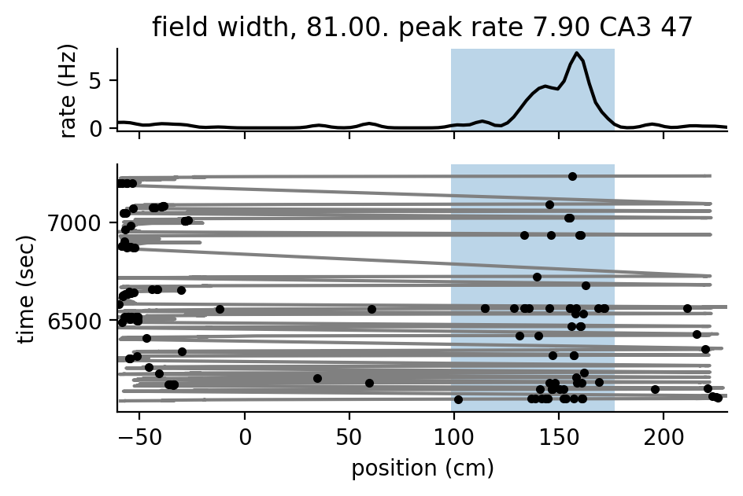

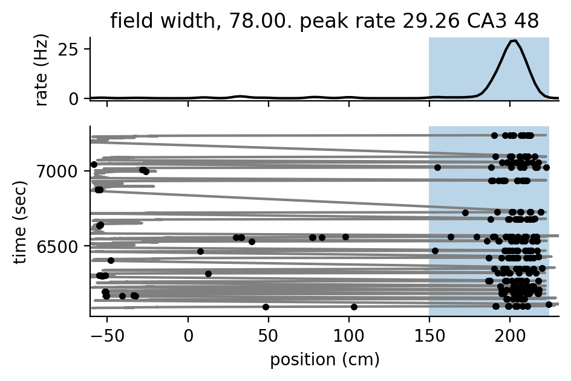

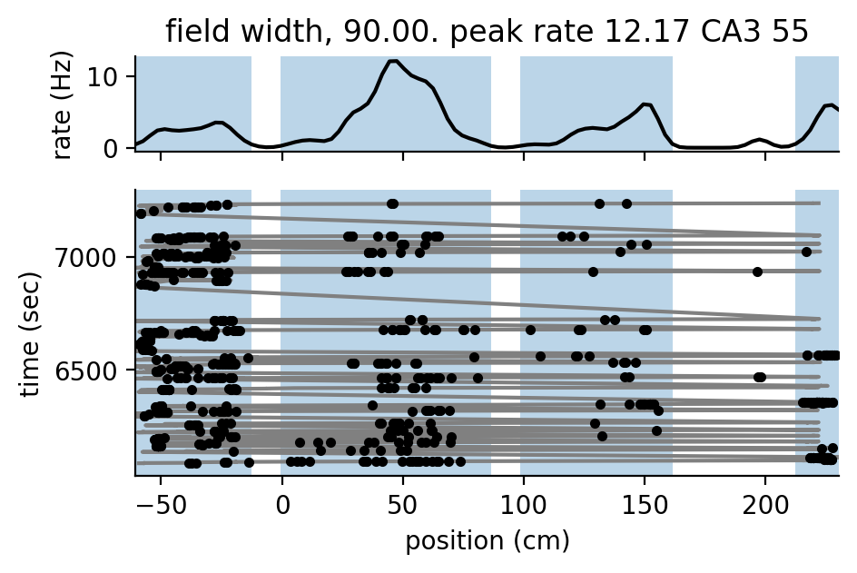